# Soil Waterlogging

Matthias Sedlmayr

`21.12.2025`

All figures and data presented in the vignette are generated from the scripts in the analysis/ folder.

This document demonstrates how to use Random Forest for digital soil mapping to predict waterlogging at a depth of 100 cm (`waterlog.100`). The workflow involves model training, variable selection, hyperparameter tuning and probabilistic predictions.

I will implement Random Forest models and try to predict if soil is waterlogged at 100cm depth with the variable waterlog.100. It is binary encoded as 1/0 and was converted into a factor.

### Load results

```r
library(dplyr)
library(here)
df_full <- readRDS(url(
  "https://raw.githubusercontent.com/geco-bern/tutorial_digital_soil_mapping/refs/heads/main/data/df_full.rds",
  "rb"  # read in binary mode
))
model_summary <- readRDS(here("data/model_summary_rf.rds"))
best_tune <- readRDS(here("data/rf_best_tune.rds"))
cv_results <- readRDS(here("data/rf_cv_results.rds"))

df_bor <- readRDS(here("data/boruta_importance.rds"))
predictors_selected <- readRDS(here("data/boruta_selected_vars.rds"))

metrics_full <- readRDS(here("data/metrics_full_rf.rds"))
metrics_bor <- readRDS(here("data/metrics_boruta_rf.rds"))
metrics_tuned <- readRDS(here("data/metrics_tuned_rf.rds"))

rf_basic <- readRDS(here("data/rf_for_waterlog100_full.rds"))
rf_bor <- readRDS(here("data/rf_for_waterlog100.rds"))
```

# 5.1 Simple model

The waterlog.100 classes observed are imbalanced, with fewer waterlogged observations than non-waterlogged ones. Consequently, overall accuracy alone is insufficient for evaluating model performance, since a model that predicts the majority class could still achieve a high accuracy score. Therefore, sensitivity, specificity, balanced accuracy and ROC-AUC provide a more informative evaluation of model performance.

```r
table(df_full$waterlog.100)
```

```
##
##   0   1
## 672 380
```

```r
prop.table(table(df_full$waterlog.100))
```

```
##
##         0         1
## 0.6387833 0.3612167
```

# 5.2 Variable selection

Models are trained in the file analysis/02_train_random_forest.r Here only the results are shown.

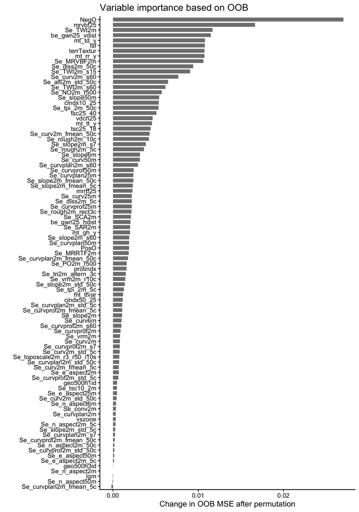

Permutation-based variable importance of the full Random Forest model.

The following displays the importance of each variable of the Boruta model. The colors show whether the variable was accepted, indefinite or rejected.

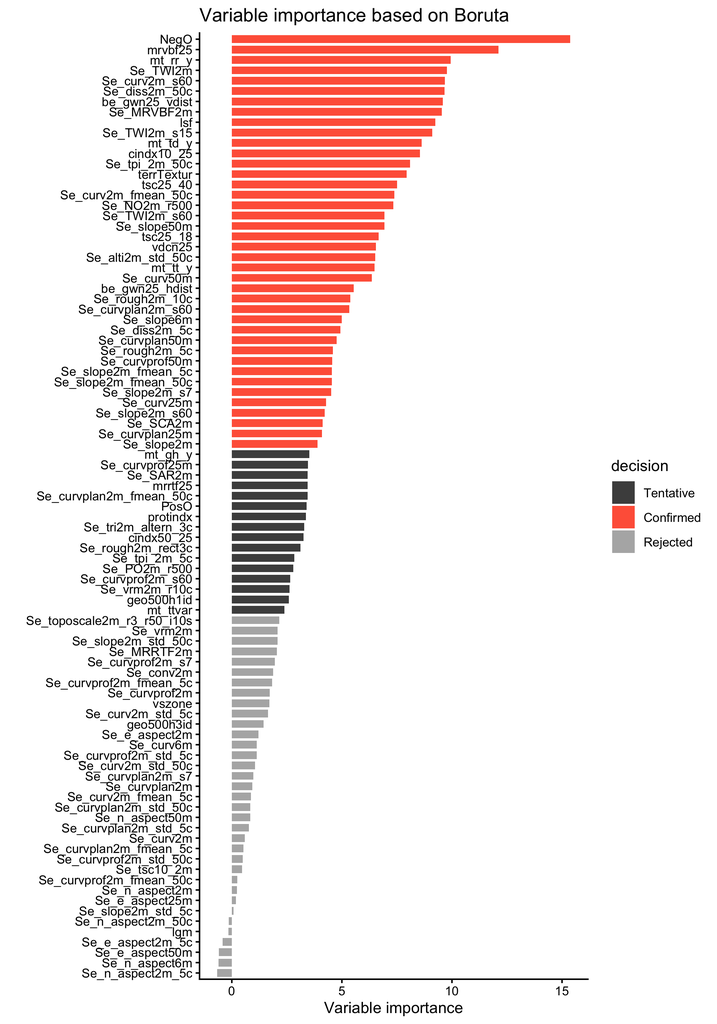

Boruta variable importance showing confirmed, tentative, and rejected predictors.

```markdown
Boruta feature selection reduced the number of predictors from
91 to 40.
```

### Model comparison table

```r
bind_rows(metrics_full, metrics_bor) |>
  knitr::kable(digits = 3)
```

| Model | Accuracy | Precision | Recall | Specificity | F1 | Balanced_Accuracy |
| --- | --- | --- | --- | --- | --- | --- |
| full_rf | 0.765 | 0.658 | 0.686 | 0.808 | 0.671 | 0.747 |
| boruta_rf | 0.795 | 0.699 | 0.729 | 0.831 | 0.713 | 0.780 |

```r
oob_errors <- tibble::tibble(
  Model = c("Full RF", "Boruta RF"),
  OOB_Error = c(
    rf_basic$prediction.error,
    rf_bor$prediction.error
  )
)

knitr::kable(oob_errors, digits = 3)
```

| Model | OOB_Error |
| --- | --- |
| Full RF | 0.213 |
| Boruta RF | 0.203 |

In my case, the full Random Forest model had an out-of-bag (OOB) error of 0.213, whereas the Boruta-reduced model had a slightly lower OOB error of 0.203. When evaluated on an independent test set, the Boruta-reduced model outperformed the full model across multiple metrics, including accuracy (0.795 vs 0.765), precision (0.699 vs 0.658), recall (0.729 vs 0.686), F1 score (0.713 vs 0.671) and balanced accuracy (0.780 vs 0.747). This demonstrates that the Boruta model generalises slightly better to unseen data. While OOB error can provide a useful initial estimate of performance, it is not always perfectly reliable as it is an internal measure that can be influenced by correlations among predictors or unpredictable observations.  
In this case, however, both OOB error and independent test-set metrics consistently indicate that the Boruta-reduced model is the better choice, so the same model choice would have been made if I only considered the OOB prediction error.

### Confusion Matrix

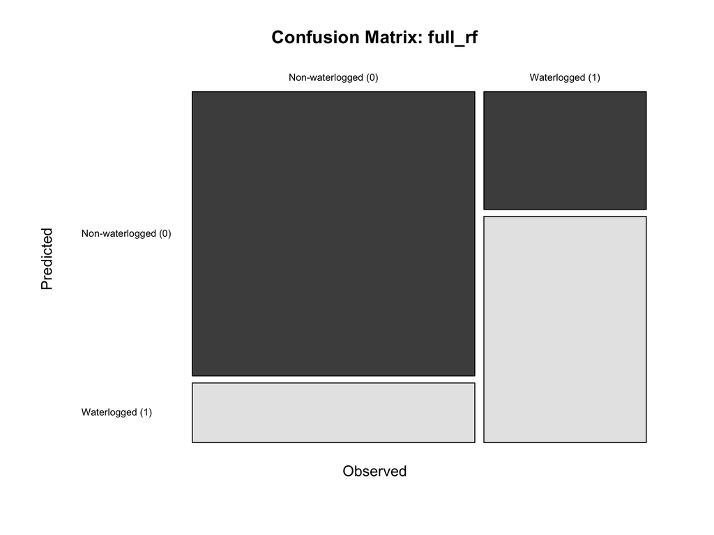

```r
knitr::include_graphics(here::here("fig/mosaic_full_rf.png"))
```

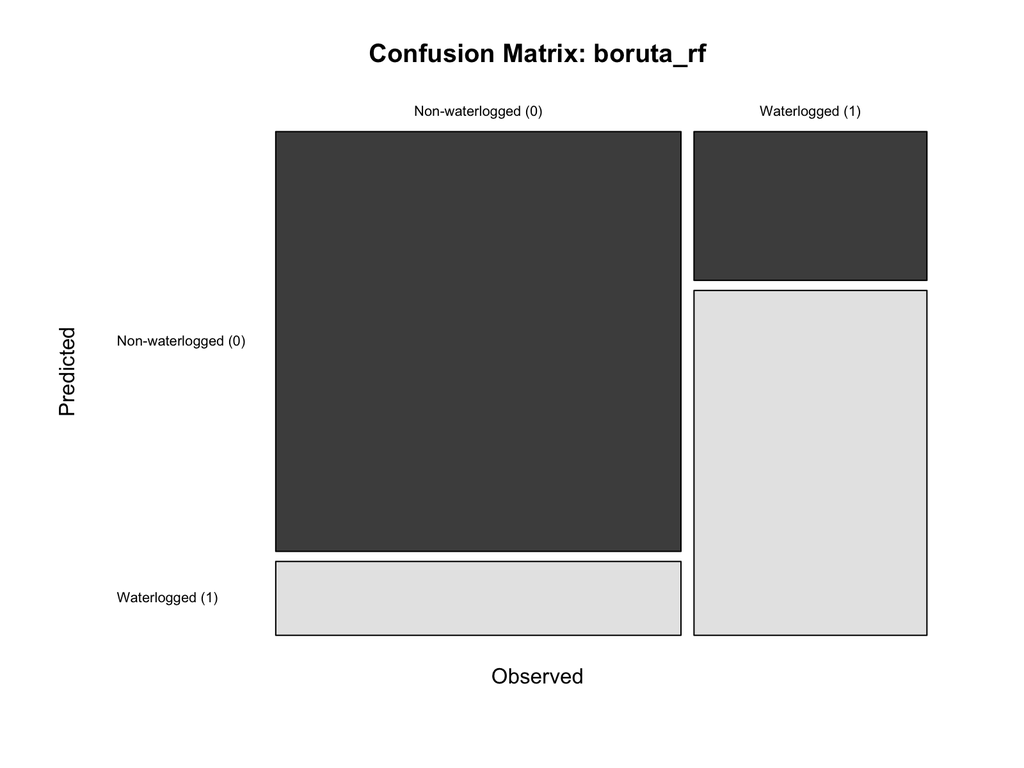

```r
knitr::include_graphics(here::here("fig/mosaic_boruta_rf.png"))
```

The mosaic plots illustrate the confusion matrices of the full Random Forest model and the Boruta-reduced model. While both models correctly classify the 0-0 and 1-1 as most dominant, but the Boruta model performs slightly better.